# Stroke

[figure not shown]

[figure not shown]

[figure not shown]

[figure not shown]

[figure not shown]

[figure not shown]

[figure not shown]

[figure not shown]

# Introducción

### **Resumen**

El stroke es una enfermedad cerebrovascular que es producida por la disminución u obstrucción del riego sanguíneo. Al no llegar correctamente el flujo sanguíneo al cerebro esto produce que las células del sistema nervioso no obtengan oxígeno.

Esta enfermedad tiene una importante causa de morbimortalidad en los países occidentales. Tiene un mayor riesgo en personas mayores de 50 años, aunque también cada vez más afecta a jóvenes.

### **Hipótesis**

- Existe relación significativa entre los factores antropomédicos y el riesgo de padecer ictus en los pacientes.

### **objetivos**

- Evaluar si existe relación entre los datos antropomédicos de los pacientes y la posibilidad de padecer stroke en función de unas variables genéricas.
- Aislar posibles pacientes que tengan un mayor factor de riesgo asociado para desarrollar la enfermedad.

### **Tabla de datos**

```
       id           gender          age        hypertension heart_disease
 Min.   :   77   Female:2897   Min.   : 0.08   No :4457     No :4665
 1st Qu.:18603   Male  :2011   1st Qu.:25.00   Yes: 451     Yes: 243
 Median :37581                 Median :44.00
 Mean   :37060                 Mean   :42.87
 3rd Qu.:55182                 3rd Qu.:60.00
 Max.   :72940                 Max.   :82.00
 ever_married         work_type    Residence_type avg_glucose_level
 No :1704     children     : 671   Rural:2418     Min.   : 55.12
 Yes:3204     Govt_job     : 630   Urban:2490     1st Qu.: 77.07
              Never_worked :  22                  Median : 91.68
              Private      :2810                  Mean   :105.30
              Self-employed: 775                  3rd Qu.:113.50
                                                  Max.   :271.74
      bmi                smoking_status      stroke
 Min.   :10.30   formerly smoked: 836   Positive: 209
 1st Qu.:23.50   never smoked   :1852   Negative:4699
 Median :28.10   smokes         : 737
 Mean   :28.89   Unknown        :1483
 3rd Qu.:33.10
 Max.   :97.60
```

# Gráficos

## Column A

### **Gráficos de distribución**

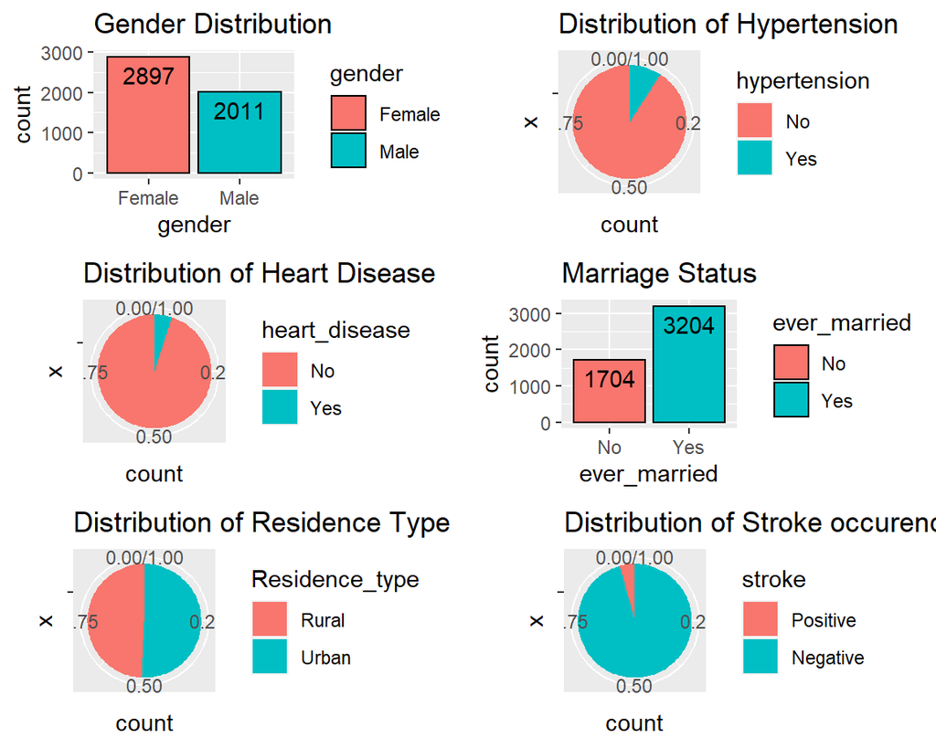

### **Gráficos de barras**

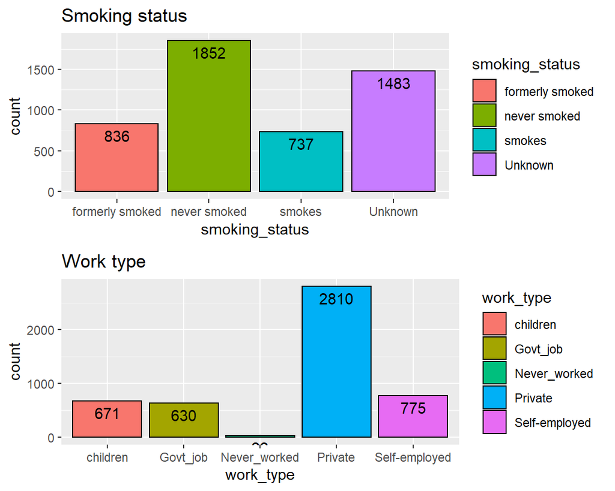

### **Histogramas bmi y glucosa-level**

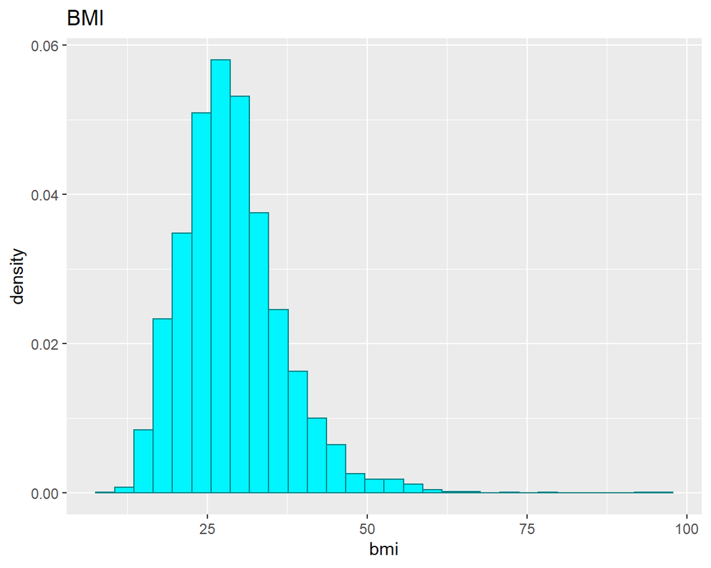

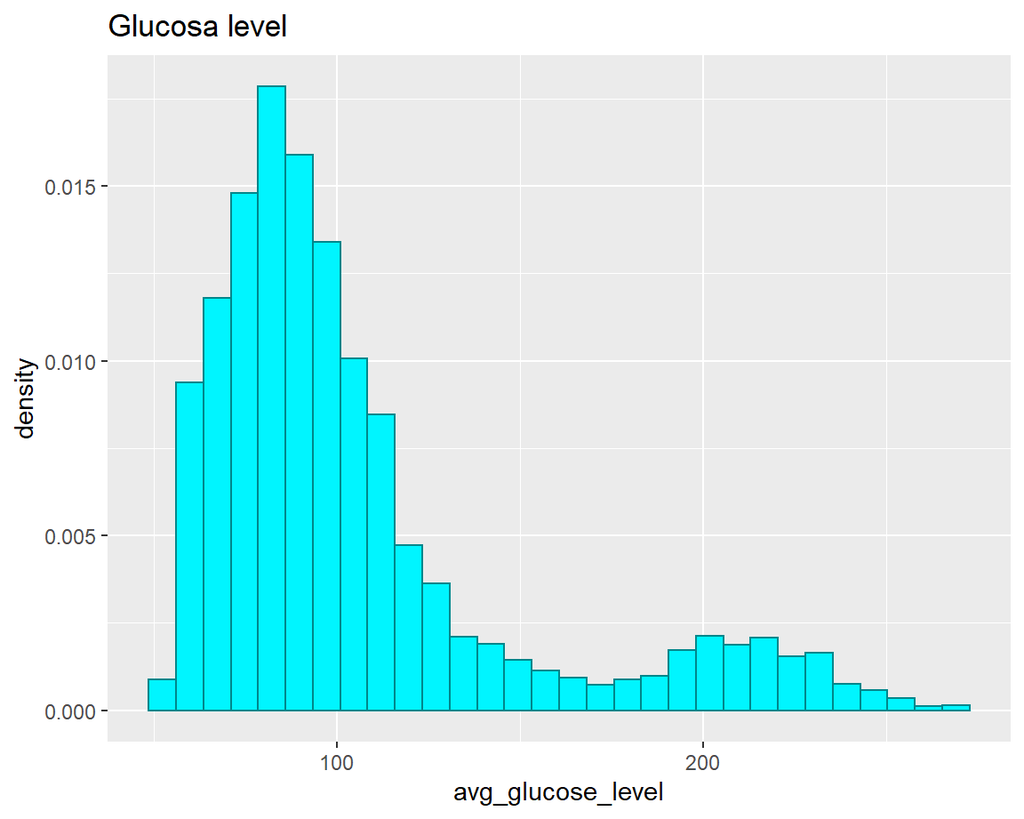

## Column B

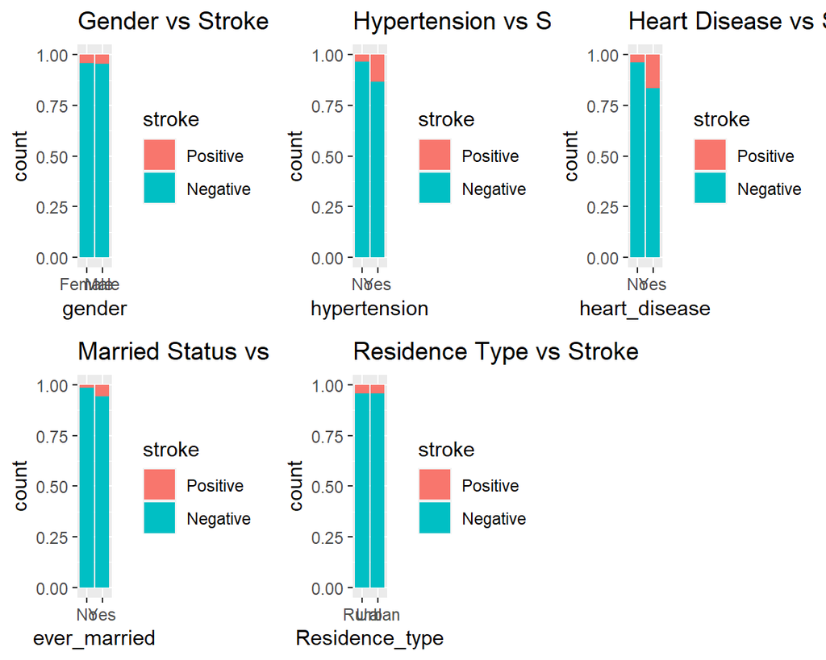

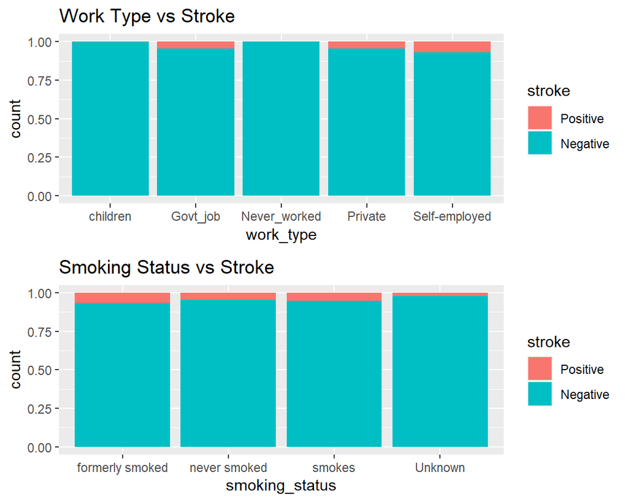

# **Prueba chi-cuadrado**

## Row A

```
    Pearson's Chi-squared test with Yates' continuity correction

data:  datos_stroke$gender and datos_stroke$stroke
X-squared = 0.16955, df = 1, p-value = 0.6805
```

```
    Pearson's Chi-squared test

data:  datos_stroke$age and datos_stroke$stroke
X-squared = 435.3, df = 103, p-value < 2.2e-16
```

```
    Pearson's Chi-squared test with Yates' continuity correction

data:  datos_stroke$hypertension and datos_stroke$stroke
X-squared = 97.239, df = 1, p-value < 2.2e-16
```

```
    Pearson's Chi-squared test with Yates' continuity correction

data:  datos_stroke$heart_disease and datos_stroke$stroke
X-squared = 90.25, df = 1, p-value < 2.2e-16
```

```
    Pearson's Chi-squared test with Yates' continuity correction

data:  datos_stroke$ever_married and datos_stroke$stroke
X-squared = 53.076, df = 1, p-value = 3.209e-13
```

## Row B

```
    Pearson's Chi-squared test

data:  datos_stroke$work_type and datos_stroke$stroke
X-squared = 41.951, df = 4, p-value = 1.708e-08
```

```
    Pearson's Chi-squared test with Yates' continuity correction

data:  datos_stroke$Residence_type and datos_stroke$stroke
X-squared = 0.12169, df = 1, p-value = 0.7272
```

```
    Pearson's Chi-squared test

data:  datos_stroke$avg_glucose_level and datos_stroke$stroke
X-squared = 4051.6, df = 3850, p-value = 0.01173
```

```
    Pearson's Chi-squared test

data:  datos_stroke$bmi and datos_stroke$stroke
X-squared = 405.9, df = 417, p-value = 0.6424
```

```
    Pearson's Chi-squared test

data:  datos_stroke$smoking_status and datos_stroke$stroke
X-squared = 35.006, df = 3, p-value = 1.215e-07
```

# **Test V de Cramer**

## Row A

```
                     X^2 df P(> X^2)
Likelihood Ratio 0.63116 52        1
Pearson          0.56443 52        1

Phi-Coefficient   : NA
Contingency Coeff.: 0.469
Cramer's V        : 0.531
```

```
                     X^2 df P(> X^2)
Likelihood Ratio 0.79091  1  0.37383
Pearson          0.69337  1  0.40502

Phi-Coefficient   : 0.589
Contingency Coeff.: 0.507
Cramer's V        : 0.589
```

```
                    X^2 df P(> X^2)
Likelihood Ratio 2.0262  1  0.15461
Pearson          1.6487  1  0.19914

Phi-Coefficient   : 0.908
Contingency Coeff.: 0.672
Cramer's V        : 0.908
```

```
                    X^2 df P(> X^2)
Likelihood Ratio 1.8018  1  0.17949
Pearson          1.5019  1  0.22038

Phi-Coefficient   : 0.867
Contingency Coeff.: 0.655
Cramer's V        : 0.867
```

## Row B

```
                     X^2 df P(> X^2)
Likelihood Ratio 0.32941  1  0.56601
Pearson          0.29567  1  0.58661

Phi-Coefficient   : 0.384
Contingency Coeff.: 0.359
Cramer's V        : 0.384
```

```
                     X^2 df P(> X^2)
Likelihood Ratio 0.58531  1  0.44424
Pearson          0.51676  1  0.47223

Phi-Coefficient   : 0.508
Contingency Coeff.: 0.453
Cramer's V        : 0.508
```

```
                     X^2 df P(> X^2)
Likelihood Ratio 0.28876  2  0.86556
Pearson          0.26064  2  0.87781

Phi-Coefficient   : NA
Contingency Coeff.: 0.34
Cramer's V        : 0.361
```

```
                    X^2 df P(> X^2)
Likelihood Ratio 1.4442  3  0.69521
Pearson          1.2128  3  0.74994

Phi-Coefficient   : NA
Contingency Coeff.: 0.602
Cramer's V        : 0.753
```

# Análisis Anova robusta

## Column A

### **Anova de varianzas**

```
              Df Sum Sq Mean Sq F value Pr(>F)
norm2          1      1  1.4455   1.388 0.2389
norm3          1      0  0.0042   0.004 0.9496
norm4          1      1  0.5449   0.523 0.4696
norm5          1      1  0.7021   0.674 0.4117
norm6          1      2  2.2977   2.206 0.1376
norm7          1      3  2.8985   2.782 0.0954 .
norm8          1      0  0.0111   0.011 0.9176
norm9          1      0  0.0167   0.016 0.8991
norm10         1      1  0.5782   0.555 0.4563
Residuals   4898   5102  1.0417
---
Signif. codes:  0 '***' 0.001 '**' 0.01 '*' 0.05 '.' 0.1 ' ' 1
```

## Column B

### **Plots**

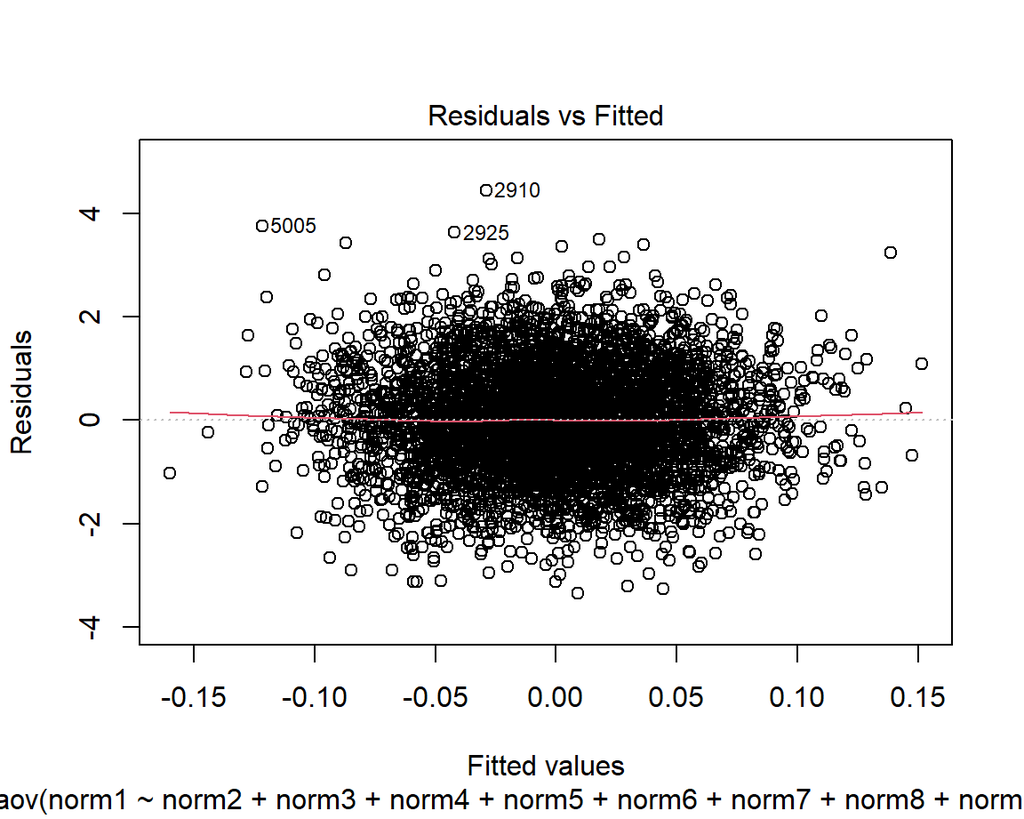

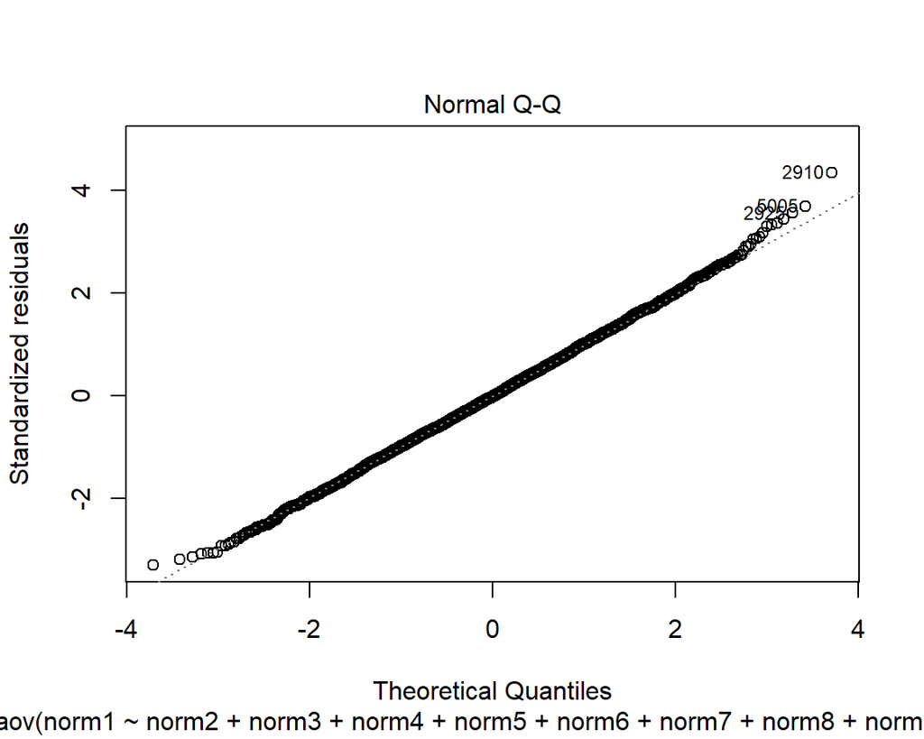

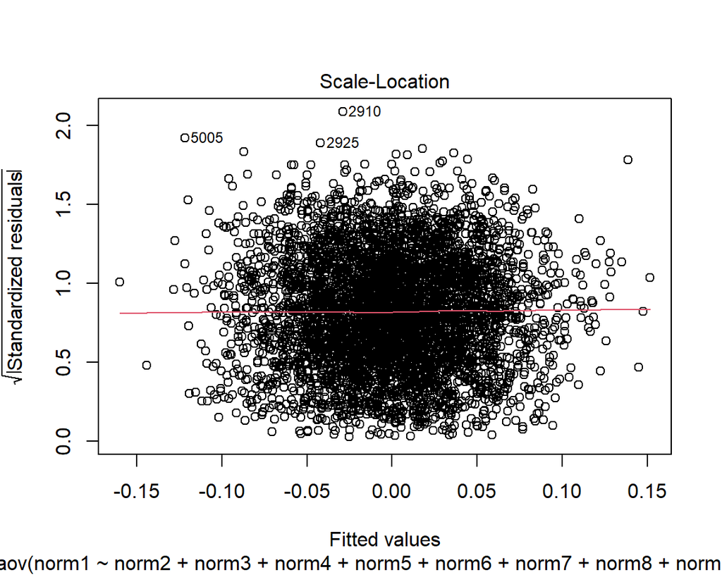

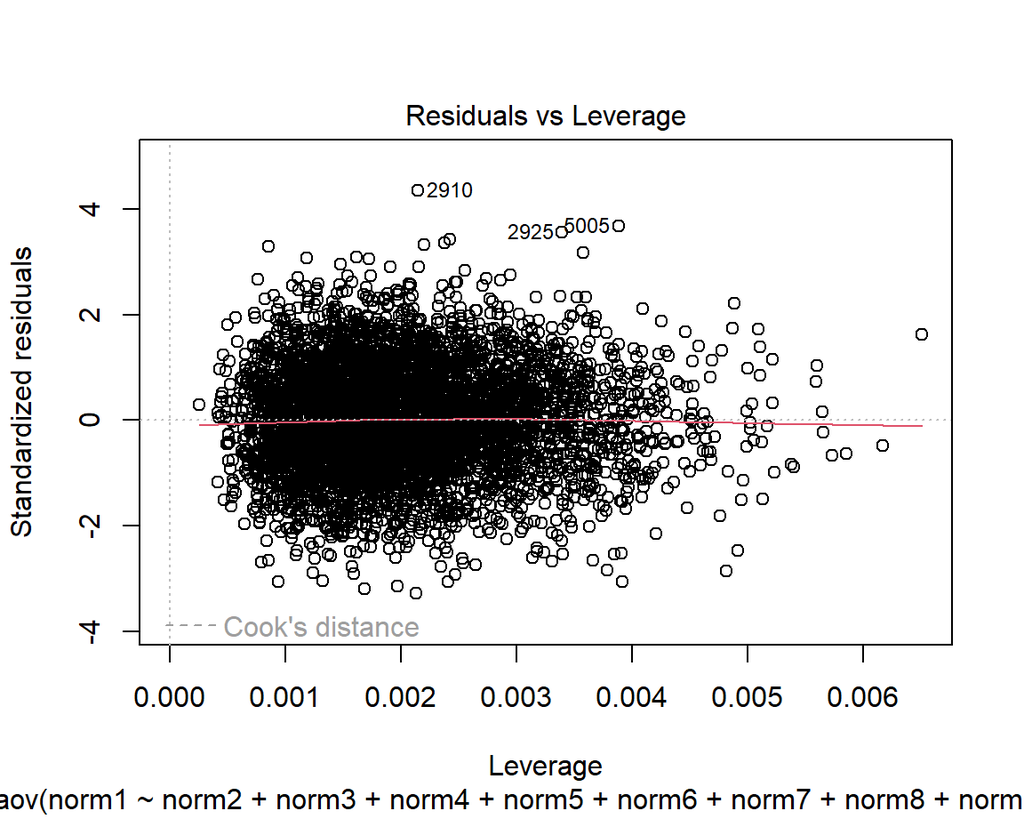

# Modelización

## Column A

### **Entrnamiento y predicción**

|  | model | seed | probab | max_J_train | sensitivity | specificity | AUC |
| --- | --- | --- | --- | --- | --- | --- | --- |
| Sensitivity | RF_threshold | 1 | 0.1 | 0.0052627 | 0.0000000 | 1.0000000 | 0.5000000 |
| 1 | RF_threshold | 2 | 0.2 | 0.0000000 | 0.0000000 | 1.0000000 | 0.5000000 |
| 2 | RF_threshold | 2 | 0.3 | 0.0000000 | 0.0000000 | 1.0000000 | 0.5000000 |
| 3 | RF_threshold | 2 | 0.4 | 0.0000000 | 0.0000000 | 1.0000000 | 0.5000000 |
| 4 | RF_threshold | 2 | 0.5 | 0.0000000 | 0.0000000 | 1.0000000 | 0.5000000 |
| 5 | RF_threshold | 2 | 0.6 | 0.0000000 | 0.0000000 | 1.0000000 | 0.5000000 |
| 6 | RF_threshold | 2 | 0.7 | 0.0000000 | 0.0000000 | 1.0000000 | 0.5000000 |
| 7 | RF_threshold | 2 | 0.8 | 0.0000000 | 0.0000000 | 1.0000000 | 0.5000000 |
| 8 | RF_threshold | 2 | 0.9 | 0.0000000 | 0.0000000 | 1.0000000 | 0.5000000 |
| Sensitivity1 | RF_threshold | 3 | 0.1 | 0.0050845 | 0.0000000 | 1.0000000 | 0.5000000 |
| Sensitivity2 | RF_threshold | 4 | 0.1 | 0.0057946 | 0.0000000 | 0.9989350 | 0.4994675 |
| Sensitivity3 | RF_threshold | 5 | 0.1 | 0.0050845 | 0.0000000 | 0.9989350 | 0.4994675 |
| 11 | RF_threshold | 6 | 0.1 | 0.0000000 | 0.0000000 | 1.0000000 | 0.5000000 |
| 21 | RF_threshold | 6 | 0.2 | 0.0000000 | 0.0000000 | 1.0000000 | 0.5000000 |
| 31 | RF_threshold | 6 | 0.3 | 0.0000000 | 0.0000000 | 1.0000000 | 0.5000000 |
| 41 | RF_threshold | 6 | 0.4 | 0.0000000 | 0.0000000 | 1.0000000 | 0.5000000 |
| 51 | RF_threshold | 6 | 0.5 | 0.0000000 | 0.0000000 | 1.0000000 | 0.5000000 |
| 61 | RF_threshold | 6 | 0.6 | 0.0000000 | 0.0000000 | 1.0000000 | 0.5000000 |
| 71 | RF_threshold | 6 | 0.7 | 0.0000000 | 0.0000000 | 1.0000000 | 0.5000000 |
| 81 | RF_threshold | 6 | 0.8 | 0.0000000 | 0.0000000 | 1.0000000 | 0.5000000 |
| 9 | RF_threshold | 6 | 0.9 | 0.0000000 | 0.0000000 | 1.0000000 | 0.5000000 |
| Sensitivity4 | RF_threshold | 7 | 0.1 | 0.0116770 | 0.0000000 | 0.9989350 | 0.4994675 |
| Sensitivity5 | RF_threshold | 8 | 0.1 | 0.0055287 | 0.0000000 | 0.9989350 | 0.4994675 |
| Sensitivity6 | RF_threshold | 9 | 0.1 | 0.0055287 | 0.0000000 | 0.9989350 | 0.4994675 |
| Sensitivity7 | RF_threshold | 10 | 0.1 | 0.0052627 | 0.0000000 | 1.0000000 | 0.5000000 |
| 12 | RF_threshold | 11 | 0.2 | 0.0000000 | 0.0000000 | 1.0000000 | 0.5000000 |
| 22 | RF_threshold | 11 | 0.3 | 0.0000000 | 0.0000000 | 1.0000000 | 0.5000000 |
| 32 | RF_threshold | 11 | 0.4 | 0.0000000 | 0.0000000 | 1.0000000 | 0.5000000 |
| 42 | RF_threshold | 11 | 0.5 | 0.0000000 | 0.0000000 | 1.0000000 | 0.5000000 |
| 52 | RF_threshold | 11 | 0.6 | 0.0000000 | 0.0000000 | 1.0000000 | 0.5000000 |
| 62 | RF_threshold | 11 | 0.7 | 0.0000000 | 0.0000000 | 1.0000000 | 0.5000000 |
| 72 | RF_threshold | 11 | 0.8 | 0.0000000 | 0.0000000 | 1.0000000 | 0.5000000 |
| 82 | RF_threshold | 11 | 0.9 | 0.0000000 | 0.0000000 | 1.0000000 | 0.5000000 |
| Sensitivity8 | RF_threshold | 12 | 0.1 | 0.0115893 | 0.0000000 | 1.0000000 | 0.5000000 |
| Sensitivity9 | RF_threshold | 13 | 0.1 | 0.0058824 | 0.0000000 | 0.9978701 | 0.4989350 |
| Sensitivity10 | RF_threshold | 14 | 0.1 | 0.0112328 | 0.0000000 | 1.0000000 | 0.5000000 |
| Sensitivity11 | RF_threshold | 15 | 0.1 | 0.0049968 | 0.0243902 | 0.9989350 | 0.5116626 |
| Sensitivity12 | RF_threshold | 16 | 0.1 | 0.0053504 | 0.0243902 | 0.9989350 | 0.5116626 |
| 13 | RF_threshold | 17 | 0.1 | 0.0000000 | 0.0243902 | 1.0000000 | 0.5121951 |
| 23 | RF_threshold | 17 | 0.2 | 0.0000000 | 0.0243902 | 1.0000000 | 0.5121951 |
| 33 | RF_threshold | 17 | 0.3 | 0.0000000 | 0.0243902 | 1.0000000 | 0.5121951 |
| 43 | RF_threshold | 17 | 0.4 | 0.0000000 | 0.0243902 | 1.0000000 | 0.5121951 |
| 53 | RF_threshold | 17 | 0.5 | 0.0000000 | 0.0243902 | 1.0000000 | 0.5121951 |
| 63 | RF_threshold | 17 | 0.6 | 0.0000000 | 0.0243902 | 1.0000000 | 0.5121951 |
| 73 | RF_threshold | 17 | 0.7 | 0.0000000 | 0.0243902 | 1.0000000 | 0.5121951 |
| 83 | RF_threshold | 17 | 0.8 | 0.0000000 | 0.0243902 | 1.0000000 | 0.5121951 |
| 91 | RF_threshold | 17 | 0.9 | 0.0000000 | 0.0243902 | 1.0000000 | 0.5121951 |
| 14 | RF_threshold | 18 | 0.1 | 0.0000000 | 0.0000000 | 1.0000000 | 0.5000000 |
| 24 | RF_threshold | 18 | 0.2 | 0.0000000 | 0.0000000 | 1.0000000 | 0.5000000 |
| 34 | RF_threshold | 18 | 0.3 | 0.0000000 | 0.0000000 | 1.0000000 | 0.5000000 |
| 44 | RF_threshold | 18 | 0.4 | 0.0000000 | 0.0000000 | 1.0000000 | 0.5000000 |
| 54 | RF_threshold | 18 | 0.5 | 0.0000000 | 0.0000000 | 1.0000000 | 0.5000000 |
| 64 | RF_threshold | 18 | 0.6 | 0.0000000 | 0.0000000 | 1.0000000 | 0.5000000 |
| 74 | RF_threshold | 18 | 0.7 | 0.0000000 | 0.0000000 | 1.0000000 | 0.5000000 |
| 84 | RF_threshold | 18 | 0.8 | 0.0000000 | 0.0000000 | 1.0000000 | 0.5000000 |
| 92 | RF_threshold | 18 | 0.9 | 0.0000000 | 0.0000000 | 1.0000000 | 0.5000000 |
| Sensitivity13 | RF_threshold | 19 | 0.1 | 0.0111451 | 0.0000000 | 1.0000000 | 0.5000000 |
| 15 | RF_threshold | 20 | 0.2 | 0.0000000 | 0.0000000 | 1.0000000 | 0.5000000 |
| 25 | RF_threshold | 20 | 0.3 | 0.0000000 | 0.0000000 | 1.0000000 | 0.5000000 |
| 35 | RF_threshold | 20 | 0.4 | 0.0000000 | 0.0000000 | 1.0000000 | 0.5000000 |
| 45 | RF_threshold | 20 | 0.5 | 0.0000000 | 0.0000000 | 1.0000000 | 0.5000000 |
| 55 | RF_threshold | 20 | 0.6 | 0.0000000 | 0.0000000 | 1.0000000 | 0.5000000 |
| 65 | RF_threshold | 20 | 0.7 | 0.0000000 | 0.0000000 | 1.0000000 | 0.5000000 |
| 75 | RF_threshold | 20 | 0.8 | 0.0000000 | 0.0000000 | 1.0000000 | 0.5000000 |
| 85 | RF_threshold | 20 | 0.9 | 0.0000000 | 0.0000000 | 1.0000000 | 0.5000000 |

## Column B

### **Modelos**

| id | age | avg_glucose_level | bmi | gender_Male | hypertension_Yes | heart_disease_Yes | ever_married_Yes | work_type_Govt_job | work_type_Never_worked | work_type_Private | work_type_Self.employed | Residence_type_Urban | smoking_status_never.smoked | smoking_status_smokes | smoking_status_Unknown | stroke |
| --- | --- | --- | --- | --- | --- | --- | --- | --- | --- | --- | --- | --- | --- | --- | --- | --- |
| -1.3319537 | 1.0557242 | 2.7449930 | 0.9788050 | 1.2042999 | -0.319997 | 4.3840680 | 0.7304827 | -0.3830001 | -0.0660639 | 0.8641937 | -0.4355118 | 0.9936361 | -0.7667119 | -0.422195 | -0.6607946 | Positive |
| -0.2842495 | 1.6287946 | 0.0062212 | 0.4573103 | 1.2042999 | -0.319997 | 4.3840680 | 0.7304827 | -0.3830001 | -0.0660639 | 0.8641937 | -0.4355118 | -1.0061313 | 1.3039165 | -0.422195 | -0.6607946 | Positive |
| 1.0960079 | 0.2622421 | 1.4631666 | 0.6989786 | -0.8301324 | -0.319997 | -0.2280367 | 0.7304827 | -0.3830001 | -0.0660639 | 0.8641937 | -0.4355118 | 0.9936361 | -0.7667119 | 2.367930 | -0.6607946 | Positive |
| 0.9292090 | 1.6728769 | 1.7973427 | 0.0121320 | 1.2042999 | -0.319997 | -0.2280367 | 0.7304827 | -0.3830001 | -0.0660639 | 0.8641937 | -0.4355118 | 0.9936361 | -0.7667119 | -0.422195 | -0.6607946 | Positive |
| -1.2660508 | 1.1438889 | -0.2509918 | -0.7764697 | -0.8301324 | -0.319997 | -0.2280367 | -1.3685859 | -0.3830001 | -0.0660639 | 0.8641937 | -0.4355118 | 0.9936361 | 1.3039165 | -0.422195 | -0.6607946 | Positive |
| -1.1871858 | 0.7912302 | 0.3305817 | 1.0042437 | -0.8301324 | -0.319997 | 4.3840680 | 0.7304827 | 2.6102558 | -0.0660639 | -1.1568336 | -0.4355118 | -1.0061313 | -0.7667119 | 2.367930 | -0.6607946 | Positive |

### **Gráfico ROC-AUC**

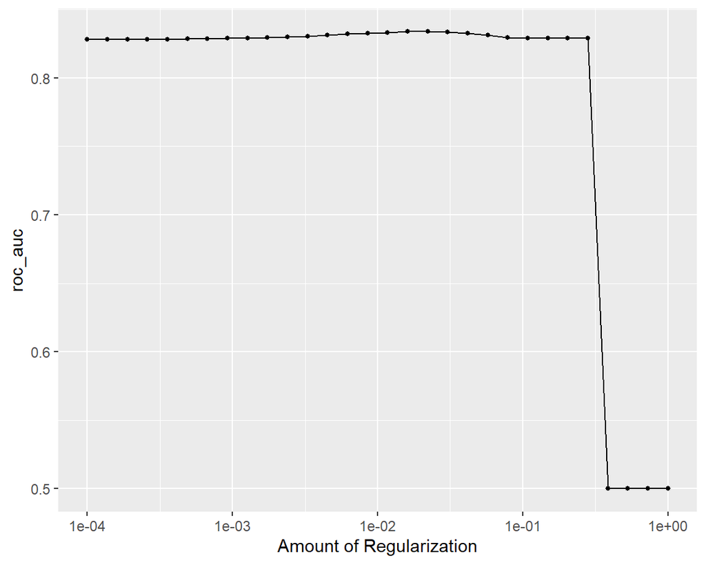

## Columna C

### **Modelos**

```
# A tibble: 5 × 7
  penalty .metric .estimator  mean     n std_err .config
    <dbl> <chr>   <chr>      <dbl> <int>   <dbl> <chr>
1 0.00853 roc_auc binary     0.833    50 0.00494 Preprocessor1_Model15
2 0.0117  roc_auc binary     0.833    50 0.00495 Preprocessor1_Model16
3 0.0161  roc_auc binary     0.834    50 0.00495 Preprocessor1_Model17
4 0.0221  roc_auc binary     0.834    50 0.00491 Preprocessor1_Model18
5 0.0304  roc_auc binary     0.833    50 0.00484 Preprocessor1_Model19
```

### **Mejor modelo**

```
# A tibble: 1 × 2
  penalty .config
    <dbl> <chr>
1  0.0221 Preprocessor1_Model18
```

### **Curva**

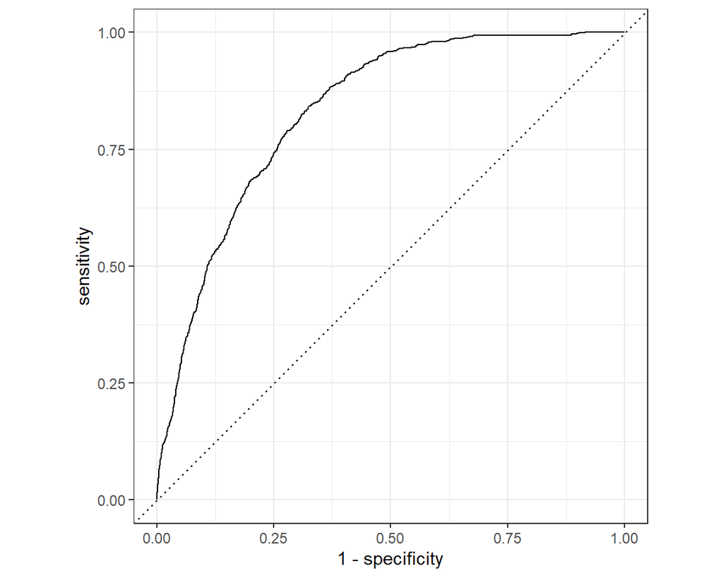

# Conclusion

Sufrir o no la enfermedad a lo largo de tu vida es una probabilidad, el estilo de vida es un factor importante a la hora de padecer la enfermedad de stroke. Aunque con los años la probabilidad aumente drásticamente como se ven en los resultados, también es importante tratar de llevar una vida saludable. Con eso conlleva no tener estrés principalmente ya que aumenta el ritmo cardiaco por lo que afecta a la salud.